# Manipulação de dados com o pacote Tidyverse

Cristiano de Carvalho Santos - Departamento de Estatística da UFMG

## Introdução

- A visualização é uma ferramenta importante para a geração de insights, mas é raro obter os dados exatamente da forma certa de que precisamos.
- Frequentemente, você
  - precisará criar algumas novas variáveis ou resumos,
  - ou talvez apenas queira renomear as variáveis
  - ou reordenar as observações para tornar os dados um pouco mais fáceis de trabalhar.

## Objetivo destes slides

Fazer uma breve introdução ao uso do pacote tidyverse para manipular conjunto de dados, apresentando as principais funções e exemplos de ilustração.

Uma visão mais aprofundada sobre os pacotes e funções que englobam o tidyverse é apresentada em vários materiais disponíveis gratuitamente, entre eles:

- https://www.tidyverse.org/packages/
- R for data Science: https://r4ds.had.co.nz/index.html
- R pragmático: https://curso-r.github.io/ragmatic-book/
- Ciência de Dados em R: https://livro.curso-r.com/index.html
- Slides do professor Walmes: http://leg.ufpr.br/~walmes/cursoR/data-vis/slides

Este conjunto de slides é baseado nos materiais citados acima!

## O que é o Tidyverse?

- Um pacote R é uma coleção de funções, dados e documentação que estende os recursos da base R.
- Os pacotes no tidyverse compartilham uma filosofia comum de programação R de dados e são projetados para trabalhar juntos naturalmente.

[figure not shown]

Você pode instalar o tidyverse completo com uma única linha de código:

```r
install.packages('tidyverse')
```

## Como é composto o tidyverse

Ao carregar o “tidyverse” no R, uma mensagem informa que o tidyverse está carregando os pacotes:

- **readr:** importar dados;
- **tibble:** auxilia na visualização de dados;
- **tidyr:** transformações no dataframe/tibble;
- **dplyr:** para manipulação de dados;
- **stringr:** trabalhar com dados do tipo string;
- **ggplot2:** visualizações gráficas;
- **purr:** programação funcional;
- **forcats:** trabalhar com fatores.

Eles são considerados o núcleo do tidyverse porque você os usará em quase todas as análises.

Os pacotes no tidyverse mudam com bastante frequência. Você pode ver se as atualizações estão disponíveis e, opcionalmente, instalá-las executando

```r
tidyverse_update()
```

## Tibble

- O data.frame é a estrutura nativa para representar tabelas de dados.
- O tibble é uma reimplementação da estrutura com melhorias.
  - Método print mais enxuto e informativo.
  - Mais consistente para seleção e modificação de conteúdo.
  - Mais fácil conversão de outros formatos para tibble.
  - Colunas/cédulas podem representar objetos mais complexos.

**Exemplo:**

```r
require(tidyverse)
tb <- as_tibble(iris)
tb
```

```
## # A tibble: 150 x 5
##    Sepal.Length Sepal.Width Petal.Length Petal.Width Species
##           <dbl>       <dbl>        <dbl>       <dbl> <fct>
##  1          5.1         3.5          1.4         0.2 setosa
##  2          4.9         3            1.4         0.2 setosa
##  3          4.7         3.2          1.3         0.2 setosa
##  4          4.6         3.1          1.5         0.2 setosa
##  5          5           3.6          1.4         0.2 setosa
##  6          5.4         3.9          1.7         0.4 setosa
##  7          4.6         3.4          1.4         0.3 setosa
##  8          5           3.4          1.5         0.2 setosa
##  9          4.4         2.9          1.4         0.2 setosa
## 10          4.9         3.1          1.5         0.1 setosa
## # ... with 140 more rows
```

Mais detalhes em:

- http://leg.ufpr.br/~walmes/cursoR/data-vis/slides/02-tibble.pdf
- https://tibble.tidyverse.org/.
- https://r4ds.had.co.nz/tibbles.html.
- https://cran.r-project.org/package=tibble

## Análise exploratória de dados (AED).

Os dados são explorados para:

- Conhecer as (propriedades das) variáveis.
- Determinar medidas descritivas.
- Comparar grupos.
- Quantificar relações entre variáveis.
- Extrair padrões.
- Detectar ameaças e corrigir problemas.

## O pacote tidyr

- Uma base **tidy** é uma base fácil de se trabalhar, isto é, fácil de se fazer manipulação de dados, criar visualizações, ajustar modelos, etc.
- Uma base **tidy** é aquela que se encaixa bem no framework do tidyverse, pois os pacotes como o **dplyr** e o **ggplot2** foram desenvolvidos para funcionar bem com bases tidy.

As propriedades mais importantes de uma base **tidy** são:

- cada coluna é uma variável;
- cada linha é uma observação;
- cada valor tem sua própria célula.

Essa definição proporciona uma maneira consistente de se referir a variáveis (nomes de colunas) e observações (índices das linhas).

O pacote **tidyr** possui funções que nos ajudam a deixar uma base bagunçada em uma base tidy. Ou nos ajuda a alterar o formato quando isto é útil para produzir os resultados que queremos.

Vamos ver aqui algumas de suas principais funções:

- `separate()` e `unite()`: para separar variáveis concatenadas em uma única coluna ou uni-las.
- `pivot_wider()` e `pivot_longer()`: para pirvotar a base.
- `nest()` e `unnest()`: para criar um quadro de dados aninhado. Separa por variáveis categoricas, uma espécie de lista dados que atendem a cada categoria da variável separadora.

## O pacote dplyr

O dplyr é o pacote mais útil para realizar transformação de dados, aliando simplicidade e eficiência de uma forma elegante.

- A funções fazem uso de verbos;
- O input é sempre uma **tibble** e o output é sempre um **tibble**.
- Colocamos a tibble no primeiro argumento e o que queremos fazer nos outros argumentos.
- O uso do operador **pipe %>%** tende a deixar os códigos mais legiveis e organizados.

As principais vantagens de se usar o **dplyr** em detrimento das funções do R base são:

- Manipular dados se torna uma tarefa muito mais simples.
- O código fica mais intuitivo de ser escrito e mais simples de ser lido.
- O pacote **dplyr** utiliza C e C++ por trás da maioria das funções, o que geralmente torna o código mais rápido.
- É possível trabalhar com diferentes fontes de dados, como bases relacionais e data.table.

Fontes:

- https://livro.curso-r.com/7-2-dplyr.html
- https://dplyr.tidyverse.org/.
- https://r4ds.had.co.nz/relational-data.html.
- https://cran.r-project.org/package=dplyr

### Principais funções

As principais funções do **dplyr** são:

- `select()` - seleciona colunas
- `arrange()` - ordena a base
- `filter()` - filtra linhas
- `mutate()` - cria/modifica colunas
- `group_by()` - agrupa a base
- `summarise()` - sumariza a base
- `rename()` - renomear colunas

Para ilustrar o uso destas funções vamos considerar os dados sobre casos e óbitos por Covid-19 no Brasil disponibilizados no pacote Covid19br.

```r
require(covid19br)
require(tidyverse)
Dados <- downloadCovid19("states") %>% as_tibble()
## Uso do operador pipe
# Equivalente a:  as_tibble( downloadCovid19("states") )

Dados
```

```
## # A tibble: 13,473 x 12
##    region state date       epi_week newCases accumCases newDeaths accumDeaths
##    <chr>  <chr> <date>        <int>    <int>      <int>     <int>       <int>
##  1 North  RO    2020-02-25        9        0          0         0           0
##  2 North  RO    2020-02-26        9        0          0         0           0
##  3 North  RO    2020-02-27        9        0          0         0           0
##  4 North  RO    2020-02-28        9        0          0         0           0
##  5 North  RO    2020-02-29        9        0          0         0           0
##  6 North  RO    2020-03-01       10        0          0         0           0
##  7 North  RO    2020-03-02       10        0          0         0           0
##  8 North  RO    2020-03-03       10        0          0         0           0
##  9 North  RO    2020-03-04       10        0          0         0           0
## 10 North  RO    2020-03-05       10        0          0         0           0
## # ... with 13,463 more rows, and 4 more variables: newRecovered <int>,
## #   newFollowup <int>, pop <dbl>, state_code <int>
```

### Função rename

Podemos estar interessados em alterar os nomes das colunas no banco de dados e, para isto, utilizar a função `rename`.

**Principais argumentos:**

- Banco de dados;
- Sintaxe: nome_novo = nome_antigo

**Exemplo:** Podemos colocar os nomes das variáveis do banco de dados sobre Covid19 em português.

```r
Dados <- Dados %>% rename(Estado = state, Regiao = region, Data = date,
                            novosCasos = newCases, novosObitos = newDeaths,
                            totalCasos = accumCases, totalObitos = accumDeaths)
Dados
```

```
## # A tibble: 13,473 x 12
##    Regiao Estado Data       epi_week novosCasos totalCasos novosObitos
##    <chr>  <chr>  <date>        <int>      <int>      <int>       <int>
##  1 North  RO     2020-02-25        9          0          0           0
##  2 North  RO     2020-02-26        9          0          0           0
##  3 North  RO     2020-02-27        9          0          0           0
##  4 North  RO     2020-02-28        9          0          0           0
##  5 North  RO     2020-02-29        9          0          0           0
##  6 North  RO     2020-03-01       10          0          0           0
##  7 North  RO     2020-03-02       10          0          0           0
##  8 North  RO     2020-03-03       10          0          0           0
##  9 North  RO     2020-03-04       10          0          0           0
## 10 North  RO     2020-03-05       10          0          0           0
## # ... with 13,463 more rows, and 5 more variables: totalObitos <int>,
## #   newRecovered <int>, newFollowup <int>, pop <dbl>, state_code <int>
```

### Função select

Podemos utilizar a função select para selecionar colunas de um banco de dados.

**Principais argumentos:**

- Banco de dados;
- Sintaxe: variáveis a serem selecionadas.

**Exemplo:** Escolhendo algumas variáveis e excluíndo outras na segundo caso.

```r
## Escolhendo 3 colunas
select(Dados, Estado, Data, novosObitos)
```

```
## # A tibble: 13,473 x 3
##    Estado Data       novosObitos
##    <chr>  <date>           <int>
##  1 RO     2020-02-25           0
##  2 RO     2020-02-26           0
##  3 RO     2020-02-27           0
##  4 RO     2020-02-28           0
##  5 RO     2020-02-29           0
##  6 RO     2020-03-01           0
##  7 RO     2020-03-02           0
##  8 RO     2020-03-03           0
##  9 RO     2020-03-04           0
## 10 RO     2020-03-05           0
## # ... with 13,463 more rows
```

```r
## Excluindo uma coluna
select(Dados, -epi_week)[1:5,]
```

```
## # A tibble: 5 x 11
##   Regiao Estado Data       novosCasos totalCasos novosObitos totalObitos
##   <chr>  <chr>  <date>          <int>      <int>       <int>       <int>
## 1 North  RO     2020-02-25          0          0           0           0
## 2 North  RO     2020-02-26          0          0           0           0
## 3 North  RO     2020-02-27          0          0           0           0
## 4 North  RO     2020-02-28          0          0           0           0
## 5 North  RO     2020-02-29          0          0           0           0
## # ... with 4 more variables: newRecovered <int>, newFollowup <int>, pop <dbl>,
## #   state_code <int>
```

Pode ser usado em conjunto com as funções:

- `starts_with()`: para colunas que começam com um texto padrão
- `ends_with()`: para colunas que terminam com um texto padrão
- `contains()`: para colunas que contêm um texto padrão

**Exemplo:** Se quisermos escolher todas as colunas que tem ‘Casos’ no final do nome.

```r
## Escolhendo colunas de casos
select(Dados, Estado, Data,  ends_with("Casos") )[1:5,]
```

```
## # A tibble: 5 x 4
##   Estado Data       novosCasos totalCasos
##   <chr>  <date>          <int>      <int>
## 1 RO     2020-02-25          0          0
## 2 RO     2020-02-26          0          0
## 3 RO     2020-02-27          0          0
## 4 RO     2020-02-28          0          0
## 5 RO     2020-02-29          0          0
```

### Função arrange

Agora suponha que precisamos ordenar o banco de dados, para isto podemos utilizar a função `arrange`. Também pode ser necessário utilizar a função `desc`.

**Principais argumentos:**

- Banco de dados;
- Variáveis usadas na ordenação.

```r
Dados %>% select(Estado, Data, ends_with("Casos") ) %>%
  arrange(Data, Estado)
```

```
## # A tibble: 13,473 x 4
##    Estado Data       novosCasos totalCasos
##    <chr>  <date>          <int>      <int>
##  1 AC     2020-02-25          0          0
##  2 AL     2020-02-25          0          0
##  3 AM     2020-02-25          0          0
##  4 AP     2020-02-25          0          0
##  5 BA     2020-02-25          0          0
##  6 CE     2020-02-25          0          0
##  7 DF     2020-02-25          0          0
##  8 ES     2020-02-25          0          0
##  9 GO     2020-02-25          0          0
## 10 MA     2020-02-25          0          0
## # ... with 13,463 more rows
```

**Exemplo:** Para ordenar em ordem decrescente de data e crescente de novos casos.

```r
Dados %>% select(Estado, Data, ends_with("Casos") ) %>%
  arrange(desc(Data), novosCasos)
```

```
## # A tibble: 13,473 x 4
##    Estado Data       novosCasos totalCasos
##    <chr>  <date>          <int>      <int>
##  1 PA     2021-07-05         27     556694
##  2 RR     2021-07-05         69     113568
##  3 AC     2021-07-05         86      85983
##  4 AP     2021-07-05        137     117927
##  5 TO     2021-07-05        195     199650
##  6 PI     2021-07-05        245     298645
##  7 AL     2021-07-05        281     220022
##  8 AM     2021-07-05        302     404347
##  9 MS     2021-07-05        317     338645
## 10 SE     2021-07-05        348     266273
## # ... with 13,463 more rows
```

Note que agora foram considerados dois critérios para reordenação das linhas.

### Função filter

Usada para filtrar um banco de dados.

**Principais argumentos:**

- Banco de dados;
- Expressões que retornam um valor lógico e são definidas em termos das variáveis.

**Exemplo:** Suponha que desejamos fazer um gráfico comparando o número de novos óbitos nos estados de Minas Gerais e Rio de Janeiro. Para isto precisamos filtra o banco de dados.

```r
DadosComp <- Dados %>% filter(Estado %in% c("MG", "RJ"))
DadosComp
```

```
## # A tibble: 994 x 12
##    Regiao    Estado Data       epi_week novosCasos totalCasos novosObitos
##    <chr>     <chr>  <date>        <int>      <int>      <int>       <int>
##  1 Southeast MG     2020-02-25        9          0          0           0
##  2 Southeast MG     2020-02-26        9          0          0           0
##  3 Southeast MG     2020-02-27        9          0          0           0
##  4 Southeast MG     2020-02-28        9          0          0           0
##  5 Southeast MG     2020-02-29        9          0          0           0
##  6 Southeast MG     2020-03-01       10          0          0           0
##  7 Southeast MG     2020-03-02       10          0          0           0
##  8 Southeast MG     2020-03-03       10          0          0           0
##  9 Southeast MG     2020-03-04       10          0          0           0
## 10 Southeast MG     2020-03-05       10          0          0           0
## # ... with 984 more rows, and 5 more variables: totalObitos <int>,
## #   newRecovered <int>, newFollowup <int>, pop <dbl>, state_code <int>
```

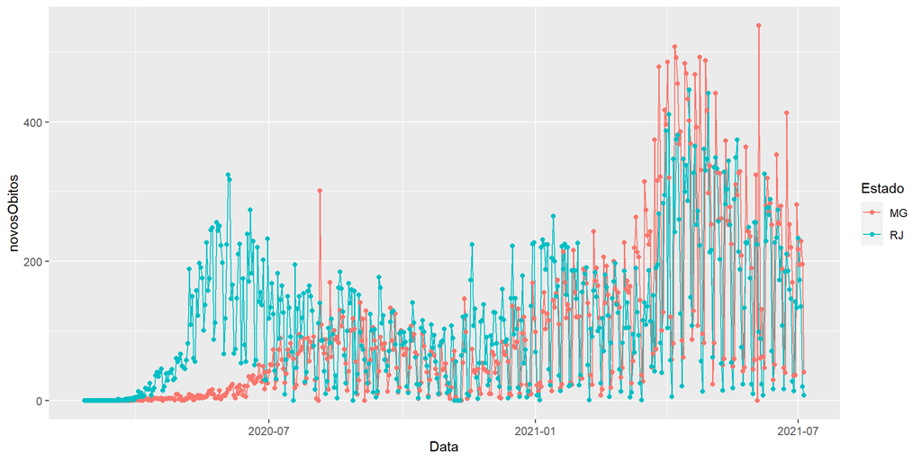

```r
ggplot(DadosComp, aes(x = Data, y = novosObitos, color = Estado)) +
  geom_line() + geom_point()
```

Note que usamos o operador `%in%` para filtrar dos dados para os estados desejados, mas existem outros operadores:

- ==, >=, <=, <, >, !=
- Função between
- A função auxiliar str_detect() do pacote `stringr` para correspondências não exatas.

**Exemplo:** Podemos estar interessados em ver os dados dos 4 primeiros meses do anos de 2021 nos estados de Minas Gerais e Rio de Janeiro.

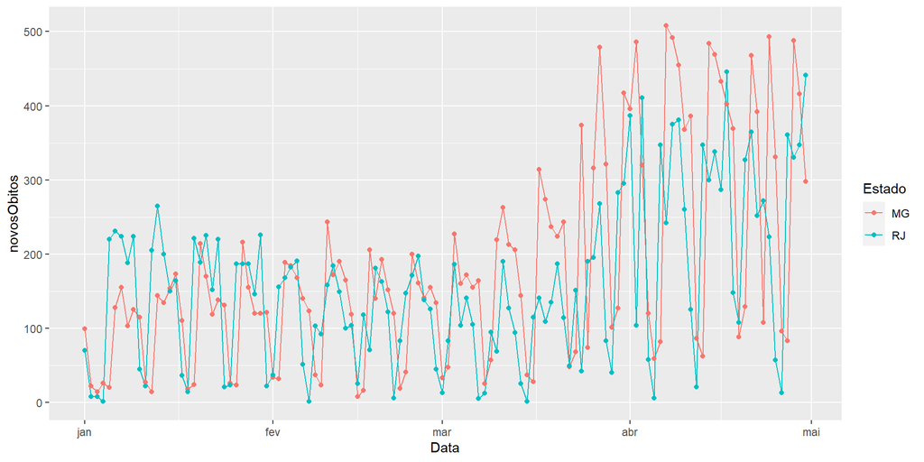

```r
require(lubridate)
DadosComp <- Dados %>%
filter( Estado %in% c("MG", "RJ"),
  between(Data, as.Date("2021-01-01"), as.Date("2021-04-30") ) )

ggplot(DadosComp, aes(x = Data, y = novosObitos, color = Estado)) +
  geom_line() + geom_point()
```

### Funções group_by e ungroup_by

- `group_by()` pega um tibble existente e o converte em um tibble agrupado onde as operações são realizadas “por grupo”.
- `ungroup()` remove o agrupamento.

**Principais argumentos:**

- Banco de dados;
- Variáveis que definem agrupamento ou para retirar agrupamento.

**Exemplo:** Criando agrupamento por região.

```r
## Filtrando para um determinada data
Dados %>% filter(Data %in% as.Date("2021-05-28")) %>%
  group_by(Regiao)
```

```
## # A tibble: 27 x 12
## # Groups:   Regiao [5]
##    Regiao    Estado Data       epi_week novosCasos totalCasos novosObitos
##    <chr>     <chr>  <date>        <int>      <int>      <int>       <int>
##  1 North     RO     2021-05-28       21        695     228358          26
##  2 North     AC     2021-05-28       21        169      82149           3
##  3 North     AM     2021-05-28       21        363     384997          15
##  4 North     RR     2021-05-28       21        118     102930           0
##  5 North     PA     2021-05-28       21       1385     514862          28
##  6 North     AP     2021-05-28       21        244     111524           2
##  7 North     TO     2021-05-28       21       1036     176801          14
##  8 Northeast MA     2021-05-28       21       1045     289019          38
##  9 Northeast PI     2021-05-28       21        644     269732          19
## 10 Northeast CE     2021-05-28       21       3186     790459         119
## # ... with 17 more rows, and 5 more variables: totalObitos <int>,
## #   newRecovered <int>, newFollowup <int>, pop <dbl>, state_code <int>
```

### Função summarise

A função summarise cria um novo banco de dados.

- Ele terá uma (ou mais) linhas para cada combinação de variáveis de agrupamento; se não houver variáveis de agrupamento, a saída terá uma única linha resumindo todas as observações na entrada.
- Ele conterá uma coluna para cada variável de agrupamento e uma coluna para cada uma das estatísticas de resumo que você especificou.

**Principais argumentos:**

- Banco de dados;
- Par nome = função

**Exemplo:** Vamos ler os dados do IBGE de projeção da população por municipios e agrupar por estado. A população do estado é dada pela soma da população dos municipios daquele estado.

Fonte:

- https://www.ibge.gov.br/estatisticas/sociais/populacao/9103-estimativas-de-populacao.html?=&t=downloads

```r
##  Lendo estimativas populacionais do IBGE
library(readxl)

read_excel("PopEstimada2020.xls") %>%
  group_by(UF) %>% summarise(PopEst=sum(Pop))
```

```
## # A tibble: 27 x 2
##    UF      PopEst
##    <chr>    <dbl>
##  1 AC      894470
##  2 AL     3351543
##  3 AM     4207714
##  4 AP      861773
##  5 BA    14930634
##  6 CE     9187103
##  7 DF     3055149
##  8 ES     4064052
##  9 GO     7113540
## 10 MA     7114598
## # ... with 17 more rows
```

```r
PopEstimada2020 <- read_excel("PopEstimada2020.xls") %>%
  group_by(UF, CODUF) %>% summarise(PopEst=sum(Pop))
PopEstimada2020
```

```
## # A tibble: 27 x 3
## # Groups:   UF [27]
##    UF    CODUF   PopEst
##    <chr> <dbl>    <dbl>
##  1 AC       12   894470
##  2 AL       27  3351543
##  3 AM       13  4207714
##  4 AP       16   861773
##  5 BA       29 14930634
##  6 CE       23  9187103
##  7 DF       53  3055149
##  8 ES       32  4064052
##  9 GO       52  7113540
## 10 MA       21  7114598
## # ... with 17 more rows
```

```r
PopEstimada2020 <- read_excel("PopEstimada2020.xls") %>%
  group_by(UF) %>% summarise(PopEst=sum(Pop), CODUF=mean(CODUF))
PopEstimada2020
```

```
## # A tibble: 27 x 3
##    UF      PopEst CODUF
##    <chr>    <dbl> <dbl>
##  1 AC      894470    12
##  2 AL     3351543    27
##  3 AM     4207714    13
##  4 AP      861773    16
##  5 BA    14930634    29
##  6 CE     9187103    23
##  7 DF     3055149    53
##  8 ES     4064052    32
##  9 GO     7113540    52
## 10 MA     7114598    21
## # ... with 17 more rows
```

**Exemplo:** Podemos escolher uma determinada data e somar os dados de casos e óbitos por Covid19 dentro de cada região.

```r
## Filtrando para um determinada data
Dados_aux <- Dados %>% filter(Data %in% as.Date("2021-05-28"))
Dados_aux
```

```
## # A tibble: 27 x 12
##    Regiao    Estado Data       epi_week novosCasos totalCasos novosObitos
##    <chr>     <chr>  <date>        <int>      <int>      <int>       <int>
##  1 North     RO     2021-05-28       21        695     228358          26
##  2 North     AC     2021-05-28       21        169      82149           3
##  3 North     AM     2021-05-28       21        363     384997          15
##  4 North     RR     2021-05-28       21        118     102930           0
##  5 North     PA     2021-05-28       21       1385     514862          28
##  6 North     AP     2021-05-28       21        244     111524           2
##  7 North     TO     2021-05-28       21       1036     176801          14
##  8 Northeast MA     2021-05-28       21       1045     289019          38
##  9 Northeast PI     2021-05-28       21        644     269732          19
## 10 Northeast CE     2021-05-28       21       3186     790459         119
## # ... with 17 more rows, and 5 more variables: totalObitos <int>,
## #   newRecovered <int>, newFollowup <int>, pop <dbl>, state_code <int>
```

```r
## Agrupando por região
Dados_regions = Dados_aux %>%
  group_by(Regiao) %>%
  summarise(novosCasos = sum(novosCasos), totalCasos = sum(totalCasos),
            novosObitos = sum(novosObitos), totalObitos = sum(totalObitos))

Dados_regions
```

```
## # A tibble: 5 x 5
##   Regiao    novosCasos totalCasos novosObitos totalObitos
##   <chr>          <int>      <int>       <int>       <int>
## 1 Midwest         7261    1694518         210       42901
## 2 North           4010    1601621          88       40910
## 3 Northeast      14788    3841637         460       94272
## 4 South          10105    3122900         393       69300
## 5 Southeast      13604    6131254        1220      211662
```

### Dados relacionais

Fonte: - https://r4ds.had.co.nz/relational-data.html

*“É raro que uma análise de dados envolva apenas um único banco de dados. Normalmente, você tem muitos bancos de dados e deve combiná-los para responder às perguntas de seu interesse. Coletivamente, vários bancos de dados são chamadas de dados relacionais porque são as relações, não apenas os conjuntos de dados individuais, que são importantes.”*

#### **Chaves**

- As variáveis usadas para conectar diferentes bancos de dados são chamadas de chaves.

Uma chave é uma variável (ou conjunto de variáveis) que identifica uma observação. Em casos simples, uma única variável é suficiente para identificar uma observação.

Existem dois tipos de chaves:

- Uma **chave primária** identifica uma observação do primeiro banco de dados $x$.
- Uma **chave estrangeira** identifica uma observação de outro banco de dados $y$.

Uma chave primária e a chave estrangeira correspondente em outro conjunto de dados formam uma relação.

As relações são geralmente de um para muitos. Por exemplo, cada voo tem um avião, mas cada avião tem muitos voos.

### **Junções**

**Junção interna:** Uma junção interna mantém as observações que aparecem simultaneamente em ambas os conjuntos de dados.

- `inner_join()`: Uma junção interna corresponde a pares de observações sempre que suas chaves são iguais. Dacartamos as linhas cujo valor das chaves aparece em apenas um dos bancos de dados.

**Junções externas:** mantém as observações que aparecem em pelo menos um dos conjuntos de dados. Existem três tipos de junções externas:

- `left_join()`: mantém todas as observações do primeiro banco de dados;
- `right_join()`: mantém todas as observações do segundo banco de dados;
- `full_join()`: mantém todas as observações dos dois bancos de dados.

**Principais argumentos:**

- x, y: Um par de bancos de dados ;
- by: Variáveis para unir (as chaves primária e estrangeira). Por exemplo, by = c(“a” = “b”, “c” = “d”) corresponderá `x$a`, `y$b`, `x$c` e `y$d`.

**Exemplo:** Criando um novo banco de dados ao acrescentar a população estimada por estado no banco de dados sobre Covid19.

```r
Dados_compl <- inner_join(Dados, PopEstimada2020, c("Estado" = "UF"))
Dados_compl
```

```
## # A tibble: 13,473 x 14
##    Regiao Estado Data       epi_week novosCasos totalCasos novosObitos
##    <chr>  <chr>  <date>        <int>      <int>      <int>       <int>
##  1 North  RO     2020-02-25        9          0          0           0
##  2 North  RO     2020-02-26        9          0          0           0
##  3 North  RO     2020-02-27        9          0          0           0
##  4 North  RO     2020-02-28        9          0          0           0
##  5 North  RO     2020-02-29        9          0          0           0
##  6 North  RO     2020-03-01       10          0          0           0
##  7 North  RO     2020-03-02       10          0          0           0
##  8 North  RO     2020-03-03       10          0          0           0
##  9 North  RO     2020-03-04       10          0          0           0
## 10 North  RO     2020-03-05       10          0          0           0
## # ... with 13,463 more rows, and 7 more variables: totalObitos <int>,
## #   newRecovered <int>, newFollowup <int>, pop <dbl>, state_code <int>,
## #   PopEst <dbl>, CODUF <dbl>
```

```r
select(Dados_compl, Estado, Data, novosCasos, PopEst)
```

```
## # A tibble: 13,473 x 4
##    Estado Data       novosCasos  PopEst
##    <chr>  <date>          <int>   <dbl>
##  1 RO     2020-02-25          0 1796460
##  2 RO     2020-02-26          0 1796460
##  3 RO     2020-02-27          0 1796460
##  4 RO     2020-02-28          0 1796460
##  5 RO     2020-02-29          0 1796460
##  6 RO     2020-03-01          0 1796460
##  7 RO     2020-03-02          0 1796460
##  8 RO     2020-03-03          0 1796460
##  9 RO     2020-03-04          0 1796460
## 10 RO     2020-03-05          0 1796460
## # ... with 13,463 more rows
```

### Função group_nest

A função group_nest pode ser utilizada para separar o banco de dados subconjuntos definidos por uma variável.

**Principais argumentos:**

- Banco de dados;
- Variável que define os subconjuntos.

**Exemplo:** Vamos dividir os dados de Covid19 por região.

```r
## Separando por região
Dados_sep <- Dados_regions %>% group_nest(Regiao)
Dados_sep
```

```
## # A tibble: 5 x 2
##   Regiao                  data
##   <chr>     <list<tibble[,4]>>
## 1 Midwest              [1 x 4]
## 2 North                [1 x 4]
## 3 Northeast            [1 x 4]
## 4 South                [1 x 4]
## 5 Southeast            [1 x 4]
```

```r
Dados_sep[[2]][[1]]
```

```
## # A tibble: 1 x 4
##   novosCasos totalCasos novosObitos totalObitos
##        <int>      <int>       <int>       <int>
## 1       7261    1694518         210       42901
```

### Função mutate

A função mutate pode ser utilizada para criar, adicionar ou alterar variáveis em um banco de dados.

**Principais argumentos:**

- Banco de dados;
- par `nome-valor` indicando nome da nova variável e cálculo por meio do qual ela é obtida;
- `.keep:` Este é um argumento experimental que permite controlar quais colunas do banco de dados original serão mantidas. Opções são: *“all”, “used”, “unused”, “none”*.

**Exemplo:** É adequado comparar diferentes estados sem levar em conta o tamanho de suas populações? Podemos criar variáveis número de novos casos ou total de casos por 100 mil habitantes para tornar a comparação justa.

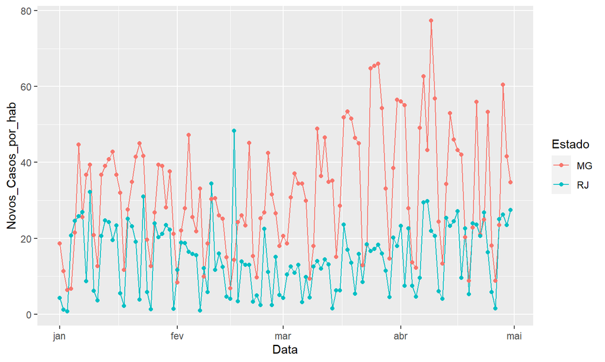

```r
Dados_compl <- Dados_compl %>%
  mutate(Casos_por_hab = totalCasos/PopEst*100000,
         Novos_Casos_por_hab = novosCasos/PopEst*100000)

DadosCompl <- Dados_compl %>%
filter( Estado %in% c("MG", "RJ"),
  between(Data, as.Date("2021-01-01"), as.Date("2021-04-30") ) )

ggplot(DadosCompl, aes(x = Data, y = Novos_Casos_por_hab, color = Estado)) +
  geom_line() + geom_point()
```

#### **Outro exemplo**

Agora queremos plotar em um mapa o número de novos casos por região.

Como obter mapa dos estados ou de regiões?

```r
# Instalar devtools antes
# devtools::install_github("rpradosiqueira/brazilmaps")
# brazilmaps foi retirado do cran em 2020
library(brazilmaps)
Dados_espaciais <- get_brmap("Region")
Dados_espaciais
```

[output not shown]

```r
# Segunda alternativa para dados espaciais
library(geobr)
read_state(year=2019, showProgress = F)
```

[output not shown]

```r
read_region(year = 2019, showProgress = F)
```

```
## Simple feature collection with 5 features and 2 fields
## Geometry type: MULTIPOLYGON
## Dimension:     XY
## Bounding box:  xmin: -73.99045 ymin: -33.75115 xmax: -28.84784 ymax: 5.271841
## Geodetic CRS:  SIRGAS 2000
##   code_region  name_region                           geom
## 1           1        Norte MULTIPOLYGON (((-46.43676 -...
## 2           2     Nordeste MULTIPOLYGON (((-38.94622 -...
## 3           3      Sudeste MULTIPOLYGON (((-48.03716 -...
## 4           4          Sul MULTIPOLYGON (((-56.32327 -...
## 5           5 Centro Oeste MULTIPOLYGON (((-57.83371 -...
```

Para mais detalhes do geobr:

- https://cran.r-project.org/web/packages/geobr/vignettes/intro_to_geobr.html

Note que os nomes das regiões estão diferentes. É preciso corrigir isto antes de tentar unir os bancos de dados.

```r
Dados_regioes <- Dados_regions %>%
  mutate(Regiao = factor(Regiao, levels=c("North", "Northeast",
                                          "Midwest", "Southeast","South"),
                        labels = c("NORTE", "NORDESTE", "CENTRO-OESTE", "SUDESTE", "SUL")))

Dados_regioes
```

```
## # A tibble: 5 x 5
##   Regiao       novosCasos totalCasos novosObitos totalObitos
##   <fct>             <int>      <int>       <int>       <int>
## 1 CENTRO-OESTE       7261    1694518         210       42901
## 2 NORTE              4010    1601621          88       40910
## 3 NORDESTE          14788    3841637         460       94272
## 4 SUL               10105    3122900         393       69300
## 5 SUDESTE           13604    6131254        1220      211662
```

Unindo os dados de Covid19 por região com dados espaciais.

Muita atenção: Faça a união apenas para dados já filtrados por uma data. Os dados dos geoespaciais são muito pesados e se forem replicados para cada data irá travar o RStudio.

```r
library(RColorBrewer)
library(sf)
dados_mapa <- Dados_espaciais %>% inner_join(Dados_regioes, c("desc_rg" = "Regiao"))
dados_mapa
```

```
## Simple feature collection with 5 features and 7 fields
## Geometry type: MULTIPOLYGON
## Dimension:     XY
## Bounding box:  xmin: -73.99045 ymin: -33.7483 xmax: -32.39705 ymax: 5.271841
## CRS:           +proj=longlat +ellps=GRS80 +no_defs
##   seq Region      desc_rg novosCasos totalCasos novosObitos totalObitos
## 1   1      1        NORTE       4010    1601621          88       40910
## 2   2      2     NORDESTE      14788    3841637         460       94272
## 3   3      3      SUDESTE      13604    6131254        1220      211662
## 4   4      4          SUL      10105    3122900         393       69300
## 5   5      5 CENTRO-OESTE       7261    1694518         210       42901
##                         geometry
## 1 MULTIPOLYGON (((-46.11427 -...
## 2 MULTIPOLYGON (((-32.39705 -...
## 3 MULTIPOLYGON (((-43.17223 -...
## 4 MULTIPOLYGON (((-54.27677 -...
## 5 MULTIPOLYGON (((-46.11427 -...
```

Agora podemos fazer o mapa!

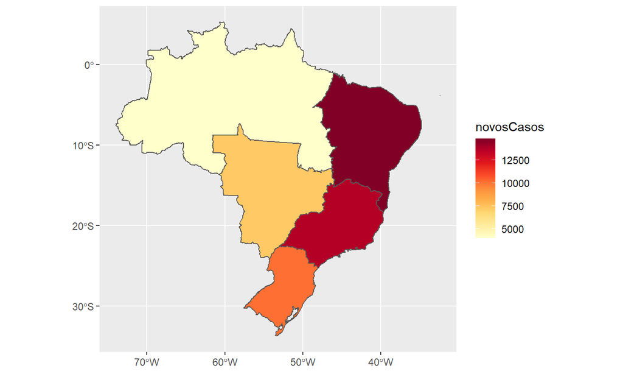

```r
ggplot(dados_mapa, aes(fill = novosCasos)) +
           scale_fill_gradientn(colours = brewer.pal(n=9,name="YlOrRd")) +
          geom_sf()
```

### Funções pivot_longer e pivot_wider - Pacote tidyr

- As funções `pivot_longer()` e `pivot_wider()` são as substitutas das funções `spread()` e `gather()`.
- No entanto as funções `spread()` e `gather()` ainda funcionam.

Essas funções são utilizadas para mudar a estrutura dos dados:

- `pivot_longer()`: Colocar no formato longo, isto é, dados empilhados.
- `pivot_wider()`: Colocar no formato largo, isto é, várias colunas podem representar a mesma variável em momentos diferentes, por exemplo.

A mudança da estrutura dos dados pode facilitar o uso de alguma função ou permitir o uso de algum recurso na visualização dos dados.

**Principais argumentos:**

- Banco de dados;
- `cols:` Variáveis que serão empilhadas;
- `names_to:` Nome dado a coluna que terá os nomes das variáveis;
- `values_to:` nome da coluna que terá os valores das variáveis;
- `names_from:` Nome dado a coluna que tem os nomes das variáveis;
- `values_from:` nome da coluna que tem os valores das variáveis.

**Exemplo:** Suponha que queremos fazer gráficos com diferentes facetas para representar novos casos de Covid19 e novos casos por 100 mil habitantes.

No **ggplot2** podemos usar a função `facet_wrap` para isto, mas precisamos ter uma coluna que define como as facetas são obtidas.

Iniciamos escolhendo algumas variáveis para trabalhar.

```r
## Escolhendo apenas algumas colunas para simplificar
Dados_aux2 <- DadosCompl %>% select(Data, Estado,novosCasos, Novos_Casos_por_hab)
Dados_aux2
```

```
## # A tibble: 240 x 4
##    Data       Estado novosCasos Novos_Casos_por_hab
##    <date>     <chr>       <int>               <dbl>
##  1 2021-01-01 MG           3975               18.7
##  2 2021-01-02 MG           2418               11.4
##  3 2021-01-03 MG           1370                6.43
##  4 2021-01-04 MG           1432                6.73
##  5 2021-01-05 MG           4588               21.5
##  6 2021-01-06 MG           9515               44.7
##  7 2021-01-07 MG           5450               25.6
##  8 2021-01-08 MG           7812               36.7
##  9 2021-01-09 MG           8399               39.4
## 10 2021-01-10 MG           4443               20.9
## # ... with 230 more rows
```

Empilhando os usando gather e pivot_longer.

```r
Dados_empilhados <- Dados_aux2 %>%
  gather("Variavel", "valor", novosCasos, Novos_Casos_por_hab)
Dados_empilhados
```

```
## # A tibble: 480 x 4
##    Data       Estado Variavel   valor
##    <date>     <chr>  <chr>      <dbl>
##  1 2021-01-01 MG     novosCasos  3975
##  2 2021-01-02 MG     novosCasos  2418
##  3 2021-01-03 MG     novosCasos  1370
##  4 2021-01-04 MG     novosCasos  1432
##  5 2021-01-05 MG     novosCasos  4588
##  6 2021-01-06 MG     novosCasos  9515
##  7 2021-01-07 MG     novosCasos  5450
##  8 2021-01-08 MG     novosCasos  7812
##  9 2021-01-09 MG     novosCasos  8399
## 10 2021-01-10 MG     novosCasos  4443
## # ... with 470 more rows
```

```r
Dados_empilhados <- Dados_aux2 %>%
  pivot_longer(cols = c(novosCasos, Novos_Casos_por_hab),
               names_to = "Variavel", values_to =  "valor" )
Dados_empilhados
```

```
## # A tibble: 480 x 4
##    Data       Estado Variavel              valor
##    <date>     <chr>  <chr>                 <dbl>
##  1 2021-01-01 MG     novosCasos          3975
##  2 2021-01-01 MG     Novos_Casos_por_hab   18.7
##  3 2021-01-02 MG     novosCasos          2418
##  4 2021-01-02 MG     Novos_Casos_por_hab   11.4
##  5 2021-01-03 MG     novosCasos          1370
##  6 2021-01-03 MG     Novos_Casos_por_hab    6.43
##  7 2021-01-04 MG     novosCasos          1432
##  8 2021-01-04 MG     Novos_Casos_por_hab    6.73
##  9 2021-01-05 MG     novosCasos          4588
## 10 2021-01-05 MG     Novos_Casos_por_hab   21.5
## # ... with 470 more rows
```

Obtendo o gráfico de interesse.

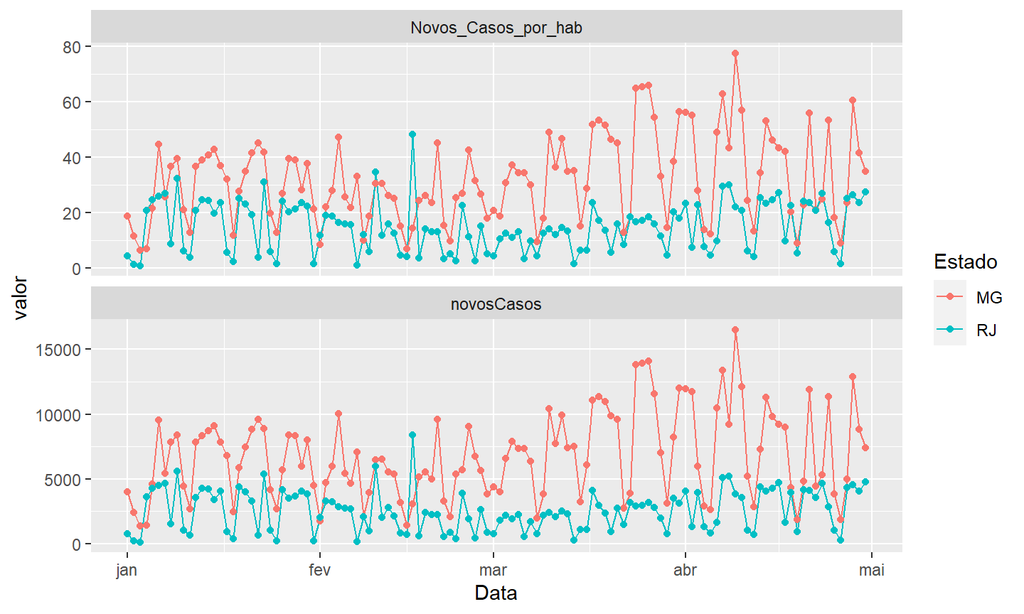

```r
ggplot(Dados_empilhados, aes(x = Data, y = valor, color = Estado)) +
  geom_line() + geom_point() + facet_wrap(~ Variavel, ncol=1, scales="free_y")
```

Voltando para o formato largo.

```r
Dados_fim <- Dados_empilhados %>%
  pivot_wider(names_from = "Variavel", values_from =  "valor" )
Dados_fim
```

```
## # A tibble: 240 x 4
##    Data       Estado novosCasos Novos_Casos_por_hab
##    <date>     <chr>       <dbl>               <dbl>
##  1 2021-01-01 MG           3975               18.7
##  2 2021-01-02 MG           2418               11.4
##  3 2021-01-03 MG           1370                6.43
##  4 2021-01-04 MG           1432                6.73
##  5 2021-01-05 MG           4588               21.5
##  6 2021-01-06 MG           9515               44.7
##  7 2021-01-07 MG           5450               25.6
##  8 2021-01-08 MG           7812               36.7
##  9 2021-01-09 MG           8399               39.4
## 10 2021-01-10 MG           4443               20.9
## # ... with 230 more rows
```

Fim!!!

Espero que tenham gostado!!!